# U-Net — 128×128

# Analiza Danych Obrazowych i Multimedialnych

### U-net

#### Antoni Brudka, Janusz Czerski, Jakub Matkowski, Jakub Zakrzewski

#### Publikacja: "U-Net: Convolutional Networks for Biomedical Image Segmentation"

#### Data realizacji: 06.06.2026

Repozytorium projektu: https://github.com/trawiasz-skuter/ADOM

Repozytorium modelu: https://github.com/milesial/pytorch-unet

Sieć U-Net to konwolucyjna sieć neuronowa (CNN) zaprojektowana pierwotnie do segmentacji obrazów medycznych przez zespół z Uniwersytetu we Fryburgu. Architektura sieci składa się ze ścieżki kurczącej się (enkodera) oraz ścieżki rozszerzającej (dekodera), co nadaje jej charakterystyczny kształt litery U.

Niniejszy notatnik prezentuje zastosowanie sieci U-Net w zadaniu segmentacji sylwetek pieszych.

- Komórka 9: Wyniki segmentacji na podstawowym zbiorze danych.
- Komórka 10: Porównanie modeli trenowanych z użyciem różnych funkcji straty.
- Komórki 11-14: Testowanie odporności sieci U-Net na geometryczne augmentacje danych.
- Komórka 15: Analiza i optymalizacja progu klasyfikacji (prawdopodobieństwa).

```python
import torch
import os
import glob
import numpy as np
import random
random.seed(0)
from PIL import Image
import matplotlib.pyplot as plt
from unet import UNet
from predict import predict_img
from myvaluate import calculate_metrics, process_images, process_images_th

# device = torch.device('cuda' if torch.cuda.is_available() else 'cpu')
device = 'cpu'
image_dir = 'Dataset/imgs/'
mask_dir  = 'Dataset/masks_saturated/'
image_path = image_dir + 'FudanPed00007.png'
mask_path  = mask_dir  + 'FudanPed00007_mask.png'
DICE_CKPT = 'checkpoints/check_dice_50.pth'
BCE_CKPT  = 'checkpoints/check_bce_50.pth'
MIX_CKPT  = 'checkpoints/check_mixed_50.pth'
target_size = (128, 128)
SAMPLE_SIZE = 60

print(f"Using device: {device}")


def load_model(checkpoint_path):
    net = UNet(n_channels=3, n_classes=2, bilinear=False)
    net.to(device=device)
    state = torch.load(checkpoint_path, map_location=device)
    state.pop('mask_values', None)
    net.load_state_dict(state)
    return net


def evaluate_on_dataset(net, img_dir, msk_dir, n=SAMPLE_SIZE, threshold = 0.5):
    files = random.sample(glob.glob(os.path.join(img_dir, '*.png')), n)
    cum = {k: 0 for k in ('TP', 'FP', 'FN', 'TN', 'total_pixels', 'edge_pixels', 'edge_accuracy')}
    for img_path in files:
        name = os.path.splitext(os.path.basename(img_path))[0]
        msk_path = os.path.join(msk_dir, name + '_mask.png')
        pred, true = process_images_th(net, img_path, msk_path, device, 0.5, True, threshold)
        true = np.array(true)[:, :, 0]
        m = calculate_metrics(pred, true)
        for k in cum:
            if k in m:
                cum[k] += m[k]

    correct   = cum['TP'] + cum['TN']
    total     = correct + cum['FP'] + cum['FN']
    precision = cum['TP'] / max(cum['TP'] + cum['FP'], 1)
    recall    = cum['TP'] / max(cum['TP'] + cum['FN'], 1)
    iou       = cum['TP'] / max(cum['TP'] + cum['FP'] + cum['FN'], 1)

    print(f"  Total pixels:     {cum['total_pixels']:,}")
    print(f"  Correct:          {correct:,}  (TP={cum['TP']:,}  TN={cum['TN']:,})")
    print(f"  False positives:  {cum['FP']:,}")
    print(f"  False negatives:  {cum['FN']:,}")
    print(f"  Pixel accuracy:   {correct / max(total, 1):.2%}")
    print(f"  Precision:        {precision:.2%}")
    print(f"  Recall:           {recall:.2%}")
    print(f"  IoU (Jaccard):    {iou:.2%}")
    print(f"  Edge pixels:      {cum['edge_pixels']:,}")
    print(f"  Edge accuracy:    {cum['edge_accuracy'] / n:.2%}")

    return {'iou': iou * 100, 'precision': precision * 100, 'recall': recall * 100}
```

```
Using device: cpu
```

## Wczytywanie modelu

```python
net_dice = load_model(DICE_CKPT)
```

## Predykcja jednej maski

```python
img = Image.open(image_path).convert('RGB').resize(target_size, Image.BILINEAR)
mask_dice = predict_img(net=net_dice, full_img=img, scale_factor=1, out_threshold=0.5, device=device)
print(f"Predicted mask shape: {mask_dice.shape}")
```

```
Predicted mask shape: (128, 128)
```

## Wizualizacja

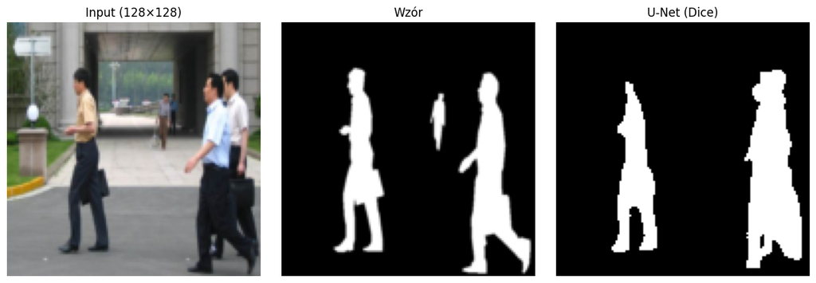

```python
img_mask = Image.open(mask_path).convert('RGB').resize(target_size, Image.BILINEAR)

fig, axes = plt.subplots(1, 3, figsize=(12, 4))
for ax, data, title in zip(axes,
                            [img, img_mask, mask_dice],
                            ['Input (128×128)', 'Wzór', 'U-Net (Dice)']):
    ax.imshow(data, cmap='gray' if isinstance(data, np.ndarray) else None)
    ax.set_title(title)
    ax.axis('off')
plt.tight_layout()
plt.show()
```

## BCE vs Dice loss

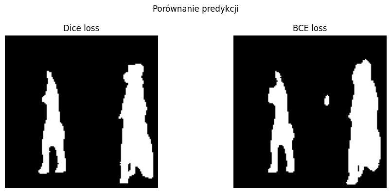

```python
net_bce = load_model(BCE_CKPT)

mask_bce = predict_img(net=net_bce, full_img=img, scale_factor=1, out_threshold=0.5, device=device)

fig, axes = plt.subplots(1, 2, figsize=(10, 4))
for ax, data, title in zip(axes, [mask_dice, mask_bce], ['Dice loss', 'BCE loss']):
    ax.imshow(data, cmap='gray')
    ax.set_title(title)
    ax.axis('off')
plt.suptitle('Porównanie predykcji')
plt.tight_layout()
plt.show()
```

## Metryki dla całego zbioru — Dice

```python
print("=== Dice model ===")
metrics_dice = evaluate_on_dataset(net_dice, image_dir, mask_dir)
```

```
=== Dice model ===
  Total pixels:     11,950,674
  Correct:          11,179,973  (TP=1,472,246  TN=9,707,727)
  False positives:  140,268
  False negatives:  630,433
  Pixel accuracy:   93.55%
  Precision:        91.30%
  Recall:           70.02%
  IoU (Jaccard):    65.64%
  Edge pixels:      227,017
  Edge accuracy:    17.24%
```

## Metryki dla całego zbioru — BCE model

```python
print("=== BCE model ===")
metrics_bce = evaluate_on_dataset(net_bce, image_dir, mask_dir)
```

```
=== BCE model ===
  Total pixels:     11,895,364
  Correct:          11,237,409  (TP=1,801,964  TN=9,435,445)
  False positives:  244,248
  False negatives:  413,707
  Pixel accuracy:   94.47%
  Precision:        88.06%
  Recall:           81.33%
  IoU (Jaccard):    73.25%
  Edge pixels:      234,629
  Edge accuracy:    22.67%
```

## Metryki dla całego zbioru — model mieszany 1:1

```python
net_mixed = load_model(MIX_CKPT)

print("=== Mixed loss model ===")
metrics_mixed = evaluate_on_dataset(net_mixed, image_dir, mask_dir)
```

```
=== Mixed loss model ===
  Total pixels:     12,393,152
  Correct:          11,833,418  (TP=1,673,976  TN=10,159,442)
  False positives:  129,010
  False negatives:  430,724
  Pixel accuracy:   95.48%
  Precision:        92.84%
  Recall:           79.54%
  IoU (Jaccard):    74.94%
  Edge pixels:      223,176
  Edge accuracy:    23.02%
```

## Analiza skrajnych błędów

Poniższa tabela przedstawia 5 najlepszych oraz 5 najgorszych predykcji modelu. Na jej podstawie można zauważyć, że sieć radzi sobie najlepiej z detekcją postaci wyraźnie odcinających się od jasnego tła.

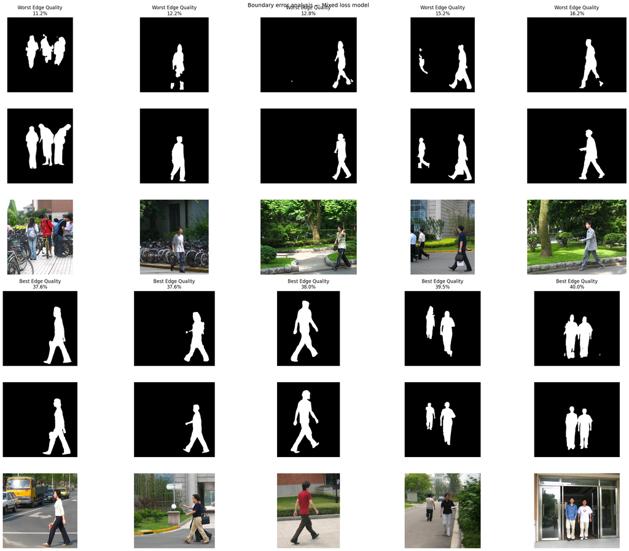

```python
results = []
img_files = glob.glob(os.path.join(image_dir, '*.png'))[:SAMPLE_SIZE]
k = 5

for tmp_img_path in img_files:
    tmp_img_name = os.path.splitext(os.path.basename(tmp_img_path))[0]
    tmp_mask_path = os.path.join(mask_dir, tmp_img_name + '_mask.png')

    pred_mask, mask_true = process_images(net_mixed, tmp_img_path, tmp_mask_path, device, 0.5, True)
    mask_true = np.array(mask_true)[:, :, 0]
    metrics = calculate_metrics(pred_mask, mask_true)

    results.append({
        'img_path':    tmp_img_path,
        'pred_mask':   pred_mask,
        'true_mask':   mask_true,
        'edge_quality': metrics['edge_quality_percent'],
    })

results_sorted = sorted(results, key=lambda x: x['edge_quality'])
worst = results_sorted[:k]
best  = results_sorted[-k:]

fig, axes = plt.subplots(6, k, figsize=(5 * k, 20))

for row, group, title in [(0, worst, 'Worst Edge Quality'), (1, best, 'Best Edge Quality')]:
    for col, item in enumerate(group):
        axes[row*3,   col].imshow(item['pred_mask'], cmap='gray')
        axes[row*3,   col].set_title(f"{title}\n{item['edge_quality']:.1f}%")
        axes[row*3,   col].axis('off')
        axes[row*3+1, col].imshow(item['true_mask'], cmap='gray')
        axes[row*3+1, col].axis('off')
        axes[row*3+2, col].imshow(Image.open(item['img_path']).convert('RGB'))
        axes[row*3+2, col].axis('off')

plt.suptitle('Boundary error analysis — Mixed loss model', fontsize=14)
plt.tight_layout()
plt.show()
```

## Porównanie modeli — IoU, Precision, Recall

W ramach eksperymentu porównano trzy modele U-Net trenowane przy użyciu różnych funkcji straty:

- BCE (Binarna entropia krzyżowa)
- Dice (Współczynnik Dice-Sørensena)
- Mixed (Średnia arytmetyczna obu powyższych funkcji)

Wnioski z porównania funkcji straty:

- Funkcja Dice wykazuje podejście bardziej konserwatywne – model generuje mniejsze, pewniejsze maski i skutecznie unika błędów typu False Positive (błędne zakwalifikowanie tła jako obiektu).
- Funkcja BCE zapewnia wyższą czułość (recall), ale kosztem niższej precyzji (precision), co objawia się tendencją do generowania szumu i nadmiarowych masek na tle.
- Model mieszany (Mixed) skutecznie równoważy zalety obu podejść, osiągając najwyższą wartość metryki IoU (Intersection over Union).

Kluczowy wniosek: Kompozycja różnych funkcji celu pozwala uzyskać model o lepszych właściwościach generalizacyjnych niż optymalizacja każdej z tych funkcji z osobna.

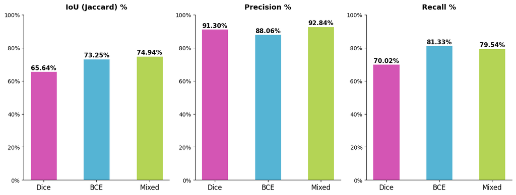

```python
models = ['Dice', 'BCE', 'Mixed']
results_all = [metrics_dice, metrics_bce, metrics_mixed]

colors = ['#D455B4', '#55B4D4', '#B4D455']
x = np.arange(len(models))

fig, axes = plt.subplots(1, 3, figsize=(13, 5))

for ax, metric, title, ymin in zip(
    axes,
    ['iou', 'precision', 'recall'],
    ['IoU (Jaccard) %', 'Precision %', 'Recall %'],
    [0, 0, 0],
):
    values = [r[metric] for r in results_all]
    bars = ax.bar(x, values, width=0.5, color=colors, edgecolor='white', linewidth=0.8)
    ax.set_title(title, fontsize=13, fontweight='bold', pad=10)
    ax.set_xticks(x)
    ax.set_xticklabels(models, fontsize=12)
    ax.set_ylim(ymin, 100)
    ax.yaxis.set_major_formatter(plt.FuncFormatter(lambda v, _: f'{v:.0f}%'))
    ax.spines[['top', 'right']].set_visible(False)
    for bar, val in zip(bars, values):
        ax.text(bar.get_x() + bar.get_width() / 2, bar.get_height() + 0.3,
                f'{val:.2f}%', ha='center', va='bottom', fontsize=11, fontweight='bold')

plt.tight_layout()
plt.show()
```

# Zbiór rozszerzony

Zbiór testowy został rozszerzony o sztuczne zniekształcenia: obroty o wielokrotność 90 stopni, odbicia lustrzane oraz przekoszenia. Celem tego testu było sprawdzenie wrażliwości modeli na zaburzenia przestrzenne.

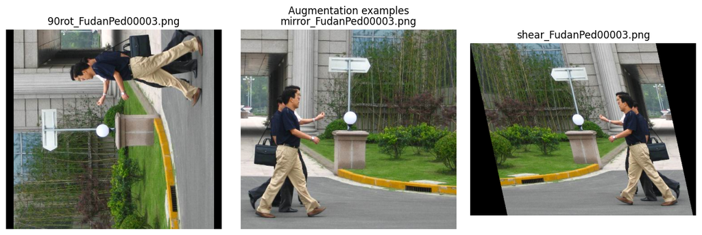

```python
a_image_dir = 'Dataset/augment/'
a_mask_dir  = 'Dataset/augment_masks/'

examples = glob.glob(os.path.join(a_image_dir, '*FudanPed00003.png'))
fig, axes = plt.subplots(1, len(examples), figsize=(4 * len(examples), 4))
if len(examples) == 1:
    axes = [axes]
for ax, p in zip(axes, examples):
    ax.imshow(Image.open(p).convert('RGB'))
    ax.set_title(os.path.basename(p))
    ax.axis('off')
plt.suptitle('Augmentation examples')
plt.tight_layout()
plt.show()
```

## Metryki dla zbioru rozszerzonego

```python
print("=== bce model on augmented data ===")
a_metrics_bce = evaluate_on_dataset(net_bce, a_image_dir, a_mask_dir)
print("=== dice model on augmented data ===")
a_metrics_dice = evaluate_on_dataset(net_dice, a_image_dir, a_mask_dir)
print("=== mixed model on augmented data ===")
a_metrics_mix = evaluate_on_dataset(net_mixed, a_image_dir, a_mask_dir)
```

```
=== bce model on augmented data ===
  Total pixels:     13,308,687
  Correct:          12,198,702  (TP=1,324,455  TN=10,874,247)
  False positives:  402,815
  False negatives:  707,170
  Pixel accuracy:   91.66%
  Precision:        76.68%
  Recall:           65.19%
  IoU (Jaccard):    54.40%
  Edge pixels:      212,151
  Edge accuracy:    17.67%
=== dice model on augmented data ===
  Total pixels:     12,815,559
  Correct:          11,540,382  (TP=1,143,214  TN=10,397,168)
  False positives:  287,742
  False negatives:  987,435
  Pixel accuracy:   90.05%
  Precision:        79.89%
  Recall:           53.66%
  IoU (Jaccard):    47.27%
  Edge pixels:      224,137
  Edge accuracy:    14.25%
=== mixed model on augmented data ===
  Total pixels:     11,741,349
  Correct:          10,730,576  (TP=1,014,419  TN=9,716,157)
  False positives:  223,465
  False negatives:  787,308
  Pixel accuracy:   91.39%
  Precision:        81.95%
  Recall:           56.30%
  IoU (Jaccard):    50.09%
  Edge pixels:      193,779
  Edge accuracy:    13.51%
```

## Analiza skrajnych błędów

Tabela prezentuje 5 najlepszych i najgorszych predykcji na zmodyfikowanym zbiorze. Odbicie lustrzane miało najmniejszy wpływ na jakość predykcji. Obroty o 90 i 270 stopni drastycznie pogorszyły wyniki. Modele w obecnej formie silnie zależą od orientacji przestrzennej i oczekują pionowej sylwetki pieszego.

Wprowadzenie transformacji geometrycznych bez wcześniejszego uwzględnienia ich w procesie treningowym (augmentacji) negatywnie wpłynęło na metryki. Średnie IoU spadło z 70% do 50%, precyzja obniżyła się o 10 punktów procentowych (pp), a czułość o około 20 pp. W tym scenariuszu model mieszany stracił przewagę na rzecz modelu BCE, który okazał się bardziej odporny na zniekształcenia i zachował wyższą czułość.

[figure not shown]

```python
results = []
img_files = random.sample(glob.glob(os.path.join(a_image_dir, '*.png')),SAMPLE_SIZE)
k = 5

for tmp_img_path in img_files:
    tmp_img_name = os.path.splitext(os.path.basename(tmp_img_path))[0]
    # print(tmp_img_name)
    # if not tmp_img_name.startswith('shear'):
    #     continue
    tmp_mask_path = os.path.join(a_mask_dir, tmp_img_name + '_mask.png')

    pred_mask, mask_true = process_images(net_bce, tmp_img_path, tmp_mask_path, device, 0.5, True)
    mask_true = np.array(mask_true)[:, :, 0]
    metrics = calculate_metrics(pred_mask, mask_true)

    results.append({
        'img_path':    tmp_img_path,
        'pred_mask':   pred_mask,
        'true_mask':   mask_true,
        'edge_quality': metrics['edge_quality_percent'],
    })

results_sorted = sorted(results, key=lambda x: x['edge_quality'])
worst = results_sorted[:k]
best  = results_sorted[-k:]

fig, axes = plt.subplots(6, k, figsize=(5 * k, 20))

for row, group, title in [(0, worst, 'Worst Edge Quality'), (1, best, 'Best Edge Quality')]:
    for col, item in enumerate(group):
        axes[row*3,   col].imshow(item['pred_mask'], cmap='gray')
        axes[row*3,   col].set_title(f"{title}\n{item['edge_quality']:.1f}%")
        axes[row*3,   col].axis('off')
        axes[row*3+1, col].imshow(item['true_mask'], cmap='gray')
        axes[row*3+1, col].axis('off')
        axes[row*3+2, col].imshow(Image.open(item['img_path']).convert('RGB'))
        axes[row*3+2, col].axis('off')

plt.suptitle('Boundary error analysis — Mixed loss model', fontsize=14)
plt.tight_layout()
plt.show()
```

## Porównanie modeli — IoU, Precision, Recall

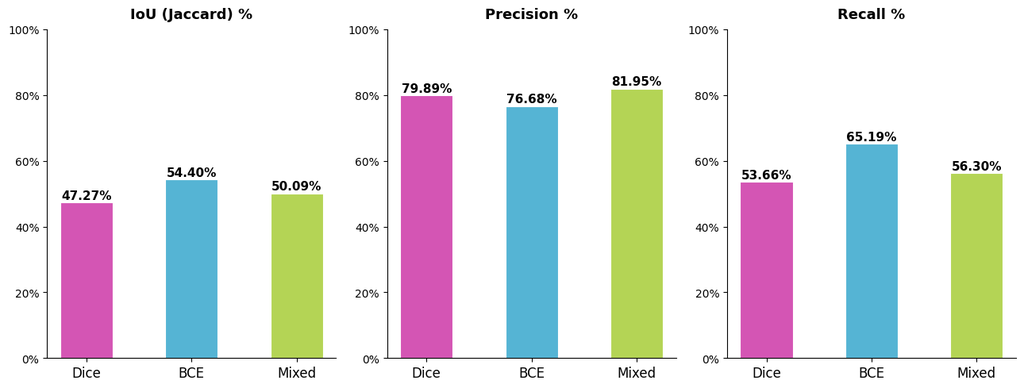

```python
models = ['Dice', 'BCE', 'Mixed']
results_all = [a_metrics_dice, a_metrics_bce, a_metrics_mix]

colors = ['#D455B4', '#55B4D4', '#B4D455']
x = np.arange(len(models))

fig, axes = plt.subplots(1, 3, figsize=(13, 5))

for ax, metric, title, ymin in zip(
    axes,
    ['iou', 'precision', 'recall'],
    ['IoU (Jaccard) %', 'Precision %', 'Recall %'],
    [0, 0, 0],
):
    values = [r[metric] for r in results_all]
    bars = ax.bar(x, values, width=0.5, color=colors, edgecolor='white', linewidth=0.8)
    ax.set_title(title, fontsize=13, fontweight='bold', pad=10)
    ax.set_xticks(x)
    ax.set_xticklabels(models, fontsize=12)
    ax.set_ylim(ymin, 100)
    ax.yaxis.set_major_formatter(plt.FuncFormatter(lambda v, _: f'{v:.0f}%'))
    ax.spines[['top', 'right']].set_visible(False)
    for bar, val in zip(bars, values):
        ax.text(bar.get_x() + bar.get_width() / 2, bar.get_height() + 0.3,
                f'{val:.2f}%', ha='center', va='bottom', fontsize=11, fontweight='bold')

plt.tight_layout()
plt.show()
```

# Threshold sweep

Ostatni etap pracy poświęcono poszukiwaniu optymalnego progu odcięcia (threshold), który mapuje prawdopodobieństwo wyjściowe sieci na maskę binarną (obiekt/tło). Wysoki próg podnosi precyzję – model klasyfikuje jako obiekt tylko te piksele, co do których ma najwyższą pewność. Niski próg zwiększa czułość i pomaga unikać błędów typu False Negative (pominięcia pikseli pieszego).

Dzięki przeprowadzeniu analizy krzywej progu (threshold sweeping) ustalono, że maksymalną wartość IoU uzyskuje się dla punktu 0.25. Dla tej wartości model mieszany osiąga IoU na poziomie 79%, co stanowi wzrost aż o 4 pp. w porównaniu do standardowego, domyślnego progu 0.5.

```
--- Dice model ---
  threshold=0.10    Total pixels:     8,097,557
  Correct:          7,635,519  (TP=1,288,575  TN=6,346,944)
  False positives:  291,657
  False negatives:  170,381
  Pixel accuracy:   94.29%
  Precision:        81.54%
  Recall:           88.32%
  IoU (Jaccard):    73.61%
  Edge pixels:      155,448
  Edge accuracy:    36.22%
  threshold=0.25    Total pixels:     8,097,557
  Correct:          7,649,974  (TP=1,181,316  TN=6,468,658)
  False positives:  169,943
  False negatives:  277,640
  Pixel accuracy:   94.47%
  Precision:        87.42%
  Recall:           80.97%
  IoU (Jaccard):    72.52%
  Edge pixels:      155,448
  Edge accuracy:    27.68%
  threshold=0.40    Total pixels:     8,097,557
  Correct:          7,613,120  (TP=1,088,772  TN=6,524,348)
  False positives:  114,253
  False negatives:  370,184
  Pixel accuracy:   94.02%
  Precision:        90.50%
  Recall:           74.63%
  IoU (Jaccard):    69.21%
  Edge pixels:      155,448
  Edge accuracy:    21.25%

--- BCE model ---
  threshold=0.10    Total pixels:     8,097,557
  Correct:          7,670,510  (TP=1,362,479  TN=6,308,031)
  False positives:  330,570
  False negatives:  96,477
  Pixel accuracy:   94.73%
  Precision:        80.47%
  Recall:           93.39%
```

[output cut: 40 more lines]

```
  Precision:        89.02%
  Recall:           87.70%
  IoU (Jaccard):    79.15%
  Edge pixels:      155,448
  Edge accuracy:    32.42%
  threshold=0.40    Total pixels:     8,097,557
  Correct:          7,752,766  (TP=1,224,560  TN=6,528,206)
  False positives:  110,395
  False negatives:  234,396
  Pixel accuracy:   95.74%
  Precision:        91.73%
  Recall:           83.93%
  IoU (Jaccard):    78.03%
  Edge pixels:      155,448
  Edge accuracy:    26.60%
```

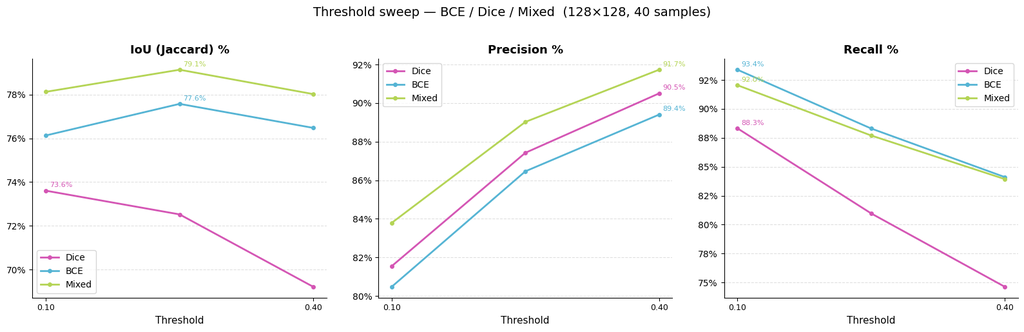

```
Best thresholds:
Model        Best IoU thr  Best Prec thr  Best Rec thr
Dice                 0.10           0.40          0.10
BCE                  0.25           0.40          0.10
Mixed                0.25           0.40          0.10
```

```python
thresholds = np.arange(0.10, 0.45, 0.15)

sweep_models = {
    'Dice':  net_dice,
    'BCE':   net_bce,
    'Mixed': net_mixed,
}

sweep_results = {name: {'iou': [], 'precision': [], 'recall': []} for name in sweep_models}

for name, net in sweep_models.items():
    print(f"\n--- {name} model ---")
    for thr in thresholds:
        print(f"  threshold={thr:.2f}", end="  ")
        random.seed(0)
        m = evaluate_on_dataset(net, image_dir, mask_dir, 40, threshold=thr)
        sweep_results[name]['iou'].append(m['iou'])
        sweep_results[name]['precision'].append(m['precision'])
        sweep_results[name]['recall'].append(m['recall'])

colors = {'Dice': '#D455B4', 'BCE': '#55B4D4', 'Mixed': '#B4D455'}
metrics_cfg = [
    ('iou',       'IoU (Jaccard) %'),
    ('precision', 'Precision %'),
    ('recall',    'Recall %'),
]

fig, axes = plt.subplots(1, 3, figsize=(16, 5))

for ax, (metric, title) in zip(axes, metrics_cfg):
    for name, color in colors.items():
        values = sweep_results[name][metric]
        ax.plot(thresholds, values, marker='o', markersize=4,
                label=name, color=color, linewidth=2)
        best_idx = int(np.argmax(values))
        ax.annotate(f"{values[best_idx]:.1f}%",
                    xy=(thresholds[best_idx], values[best_idx]),
                    xytext=(4, 4), textcoords='offset points',
                    fontsize=8, color=color)
    ax.set_title(title, fontsize=13, fontweight='bold')
    ax.set_xlabel('Threshold', fontsize=11)
    ax.set_xticks(thresholds[::2])
    ax.set_xticklabels([f'{t:.2f}' for t in thresholds[::2]], fontsize=9)
    ax.yaxis.set_major_formatter(plt.FuncFormatter(lambda v, _: f'{v:.0f}%'))
    ax.spines[['top', 'right']].set_visible(False)
    ax.legend(fontsize=10)
    ax.grid(axis='y', linestyle='--', alpha=0.4)

plt.suptitle('Threshold sweep — BCE / Dice / Mixed  (128×128, 40 samples)',
             fontsize=14, y=1.02)
plt.tight_layout()
plt.show()

# Best threshold per model × metric
print("\nBest thresholds:")
print(f"{'Model':<10} {'Best IoU thr':>14} {'Best Prec thr':>14} {'Best Rec thr':>13}")
for name in sweep_models:
    best = {m: thresholds[int(np.argmax(sweep_results[name][m]))] for m, _ in metrics_cfg}
    print(f"{name:<10} {best['iou']:>14.2f} {best['precision']:>14.2f} {best['recall']:>13.2f}")
```

# Podsumowanie

Sieć U-Net skutecznie realizuje zadanie segmentacji sylwetek pieszych, osiągając IoU przekraczające 79% w optymalnej konfiguracji. Najlepszą kombinacją okazał się model trenowany na mieszanej funkcji straty (Mixed) z progiem odcięcia 0.25 - uzyskuje on najwyższe IoU (79,15%), wysoką precyzję (89,02%) i czułość (87,70%).

Kluczową słabością wszystkich modeli jest brak odporności na rotacje, co wskazuje na konieczność rozszerzenia augmentacji treningowej o transformacje geometryczne jeżeli oczekiwane obrazy mogą nie być w pełni pionowe, mieć zaburzenia spowodowane np. soczewką kamery.